# Fitness Tracker Analysis

Kyle Wheatley

## Introduction

The case study was introduced as if I was a junior analyst working on the marketing analyst team for a company called *Bellabeat*, a manufacturer of health-focused products for women. I was asked by the company’s CCO to analyize smart device usage data in order to gain insight into how customers use their competitor’s devices. I was then asked to select one product and apply the insights to possible innovations. The dataset used was provided thru Mobius (CC0: Public Domain). The link can be found [here.](https://www.kaggle.com/arashnic/fitbit)

## Cleaning and Organizing

The data given was in 18 different .csv files. The individual files contained data organized by the day, hour, and minute and organized in wide and narrow formats. RStudio was used to clean, organize, and analyze the data. Tidyverse, skimr, lubridate, janitor, and ggpubr packages were used in these processes. `df <- read.csv(file.csv)` was used to import all 18 datasets. Next `glimpse(df)` was used to view column names and data types. The column names were all very different so they were renamed to be uniform; `rename_with(df, tolower)` and `rename(df, cols)` were used to ensure uniformity.

Due to there being many different datasets, I chose to make a larger parent file of the daily and hourly sets that included all of the data collected in the day or hour. In many instances ID and Activity were not the correct data type so I had to convert it from number to character. I used inner joins to create the data sets: `daily_total <- inner_join(daily_activity, daily_calories, daily_intensities, daily_sleep, daily_steps, by = c('id', 'activity_date'))` `hourly_total <- inner_join(hourly_calories, hourly_intensities, hourly_steps, by = c('id', 'activity_date'))`

## Analysis

I began with the idea of comparing the calories burned by the smart device users and the average number of calories burned by the average American woman. According to the U.S. Department of Health and Human Services (HHS), the average woman age 18+ needs to consume 1800 and 2400 calories per day to maintain an “active” lifestyle where it is assumed that there will be deficit of caloric intake compared to caloric usage. I began to create additional data sets focusing on daily activity - specifically related to very active and fairly active minutes per day, calories burned per day, and the amount of time spent in bed per day. I created a new dataset from the daily_calories, daily_activity, and daily_sleep datasets using: `active_minutes_sleep_calories <- inner_join(daily_calories, daily_intensities, daily_sleep, by = c('id', 'activity_date'))`. At this point I observed the data and made the decision to not include any intensity data below the level of “fairly active” to focus on activity that would have likely have active heart rates and only count. I also kept the total time in bed column because many adults find themselves spending more time in bed watching TV or being on their phones before or after sleeping which will add to a sedentary lifestyle: `active_minutes_sleep_calories = subset(active_minutes_sleep_calories,select = -c(sendaryminutes,` `lightlyactiveminutes, sedntaryactivedistance, lightactivedistance, modersatelyactivedistance, veryactivedistance, totalminutesasleep, totalsleeprecords))`. From this point I created a total active minutes column by adding the two remaining categories: `mutate(total_active_minutes = veryactiveminutes + fairlyactiveminutes)`.

I began mapping out visualizations to see if there is any correlation between the active minutes, calories burned, and the amound of time spent in bed. In doing so I found there to be 134 instances where there were calories burned but no active minutes shown in the data; I removed those instances using: `active_minutes_sleep_calories_null_removed <- active_minutes_sleep_calories %>% filter(total_active_minutes > 0)`. Next set up a series of ranges in for this data set to compartmentalize the data into groups that have logical application. Calories were grouped into 1000 calorie groups; active minutes were grouped into half our increments. I also created a column that identifies if the user acheived the goal of expending 2100 calories (the midpoint of range identified by the US HHS). `daily_total$hhs_daily_goal[daily_total$calories >= 2100] <- 'Yes' daily_total$hhs_daily_goal[daily_total$calories <= 2100] <- 'No'`

I began looking at combinations of data to see if any of them had a correlation together. I assembled many different plot arrangements. Eventually I found correlative data between the recorded calories burned and the number of minutes active. This was done by using the Pearson correlation coefficient.

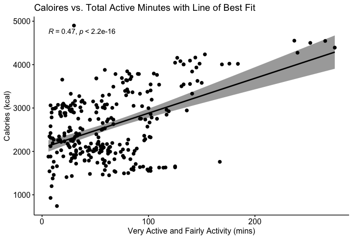

There is a positive correction (R=0.47) with a p-value being very close to 0, the chance that a person would burn more calories over more strenuous activity is not due to chance alone.

## Conclusion

While this may not be a world changing revelation, it does have an impact on the decisions being made when dealing with motivation to lead an active lifestyle. According to an [article](https://www.ncbi.nlm.nih.gov/pmc/articles/PMC6958644/) by the National Library of Medicine-National Center for Biotechnology Information, 83.3% of the participants found the motivational cues to be most helpful. The study was also 81% female. The following chart shows the number of times the HHS goal of 2100 calories was met.

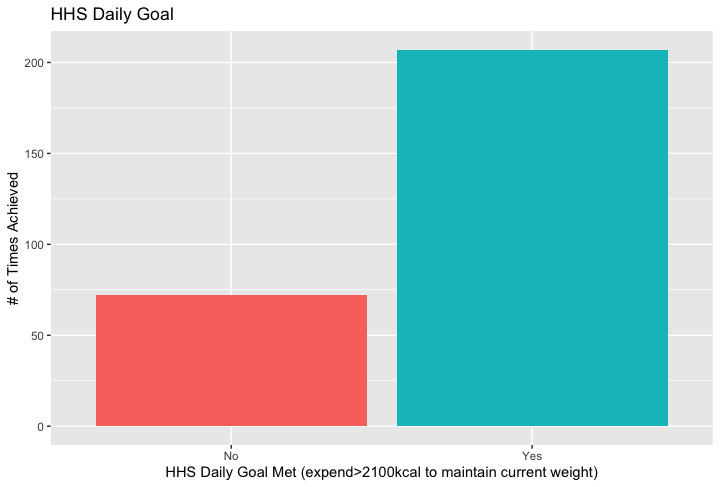

This data shows that the number of times the HHS goal was met (207) is significantly larger than the number that did not (72). This is a good sign; however, when the range of minutes of activity is observed there is a gamma distribution in the amount of instances per grouping.

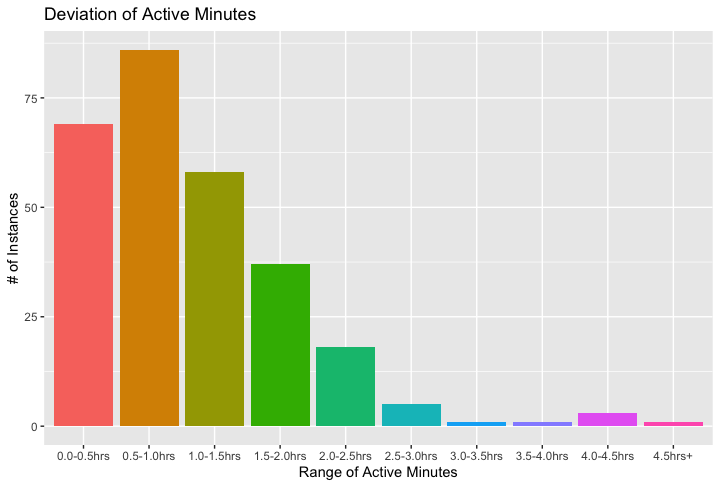

The majority of the instances (154) lie at or below the suggested amount of cardiovascular activity (1.0hrs)

The greater implication can be made to the *Bellabeat Ivy Health Tracker* to made changes to the device to add some way to create motivaitonal cues to be more active throughout the day and to acheive at least 1hr of cardiovascular activity per day. Recommendations: - Add digial screen to be able to add prompts for activity - Add vibration haptics to get the user to check their phone and have notification for movement

This case study was completed in partical fulfillment for the Google Data Analytics Certification. The full RStudio file and corresponding files can be found [here](https://kylewheatley.github.io/fitness-tracker-analysis/)